The format of this lab follows the same format as the previous ones. Your goal is to predict the value of the third column (which will be missing on the test set) using the techniques we have learned so far.

# Set-up

Read in the following libraries and to load the metadata:

```r
library(readr)
library(dplyr)
```

```r
library(ggplot2)
library(viridis)
library(stringi)
library(methods)
library(keras)
fashion <- read_csv("https://statsmaths.github.io/ml_data/fashion_10.csv")
```

To get the actual data for the images, you’ll have to download the following file.

- https://drive.google.com/open?id=0B6_9OUDRaPQsTFU5SWpNZG1tbTg

Once these are downloaded, you’ll have to run something like this:

```r
x28 <- read_rds("~/Desktop/fashion_10_x28.rds")
```

If, for example, the file sits on your Desktop and you have a Mac. If you have trouble with any of this, please let me know as soon as possible.

# Lab 19

Before we dig in, let us take a closer look at the categories and some example pictures.

```r
table(y=fashion$class_name, x=fashion$class)
```

```
##           x
## y             0    1    2    3    4    5    6    7    8    9
##   bag         0    0    0    0    0    0    0    0 5250    0
##   boot        0    0    0    0    0    0    0    0    0 5250
##   coat        0    0    0    0 5250    0    0    0    0    0
##   dress       0    0    0 5250    0    0    0    0    0    0
##   pullover    0    0 5250    0    0    0    0    0    0    0
##   sandal      0    0    0    0    0 5250    0    0    0    0
##   shirt       0    0    0    0    0    0 5250    0    0    0
##   sneaker     0    0    0    0    0    0    0 5250    0    0
##   trouser     0 5250    0    0    0    0    0    0    0    0
##   tshirt   5250    0    0    0    0    0    0    0    0    0
```

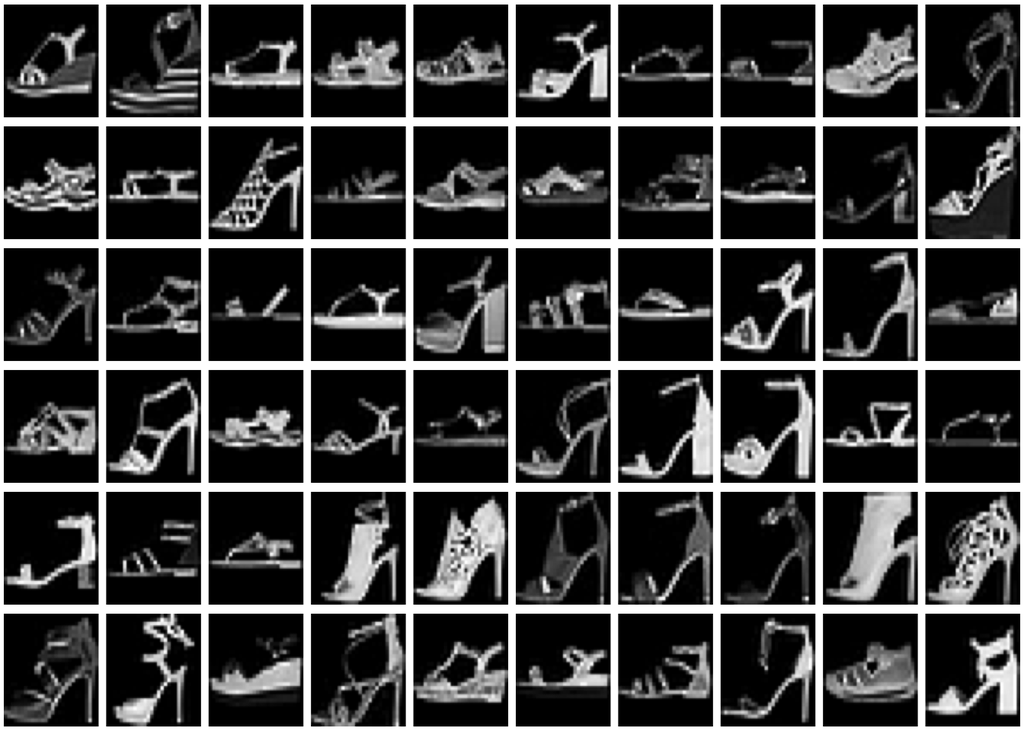

```r
par(mar = c(0,0,0,0))
par(mfrow = c(6, 10))
for (i in sample(which(fashion$class == 5), 60)) {
  plot(0,0,xlim=c(0,1),ylim=c(0,1),axes= FALSE,type = "n")
  rasterImage(x28[i,,,],0,0,1,1)
}
```

```r
dim(x28)
```

```
## [1] 70000    28    28     1
```

Lets create a dataframe for our data.

```r
X <- t(apply(x28, 1, cbind))
X_train <- X[fashion$train_id == "train",]

y <- fashion$class
y_train <- to_categorical(y[fashion$train_id == "train"], num_classes = 10)
```

```r
model <- keras_model_sequential()
model %>%

    layer_dense(units = 128, kernel_initializer = "glorot_normal",
                input_shape = c(28^2)) %>%
    layer_activation(activation = "relu") %>%
    layer_dropout(rate = 0.15) %>%

    layer_dense(units = 128, kernel_initializer = "glorot_normal") %>%
    layer_activation(activation = "relu") %>%
    layer_dropout(rate = 0.15) %>%

    layer_dense(units = 128, kernel_initializer = "glorot_normal") %>%
    layer_activation(activation = "relu") %>%
    layer_dropout(rate = 0.15) %>%

    layer_dense(units = 10) %>%
    layer_activation(activation = "softmax")


model%>% compile(loss = 'categorical_crossentropy',
                 optimizer = optimizer_sgd(lr = 0.001, momentum = 0.9,
                                           nesterov = TRUE),
                 metrics = c('accuracy'))

model
```

```
## Model
## ___________________________________________________________________________
## Layer (type)                     Output Shape                  Param #
## ===========================================================================
## dense_1 (Dense)                  (None, 128)                   100480
## ___________________________________________________________________________
## activation_1 (Activation)        (None, 128)                   0
## ___________________________________________________________________________
## dropout_1 (Dropout)              (None, 128)                   0
## ___________________________________________________________________________
## dense_2 (Dense)                  (None, 128)                   16512
## ___________________________________________________________________________
## activation_2 (Activation)        (None, 128)                   0
## ___________________________________________________________________________
## dropout_2 (Dropout)              (None, 128)                   0
## ___________________________________________________________________________
## dense_3 (Dense)                  (None, 128)                   16512
## ___________________________________________________________________________
## activation_3 (Activation)        (None, 128)                   0
## ___________________________________________________________________________
## dropout_3 (Dropout)              (None, 128)                   0
## ___________________________________________________________________________
## dense_4 (Dense)                  (None, 10)                    1290
## ___________________________________________________________________________
## activation_4 (Activation)        (None, 10)                    0
## ===========================================================================
## Total params: 134,794
## Trainable params: 134,794
## Non-trainable params: 0
## ___________________________________________________________________________
```

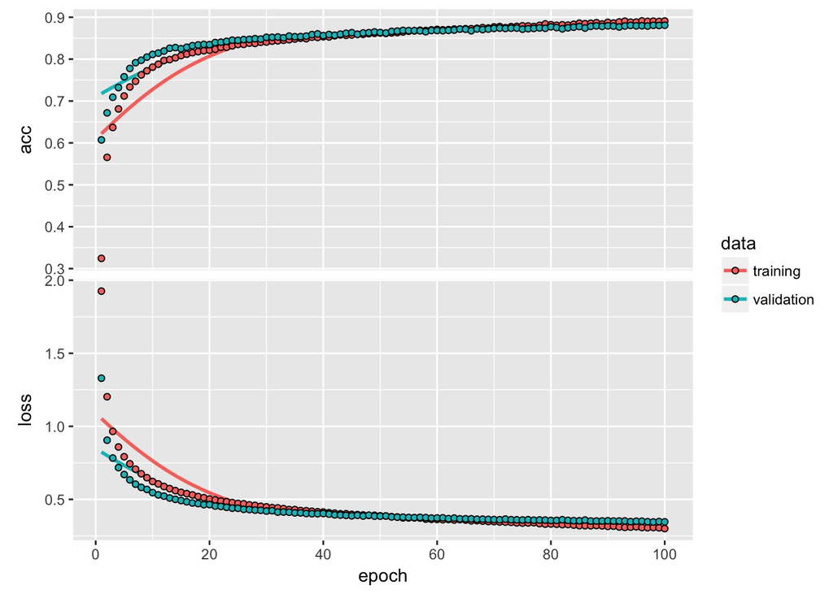

```r
history <- model %>%
  fit(X_train, y_train, epochs = 100, validation_split = 0.2,
      batch_size = 128)

plot(history)
```

Looking at how the model does on the real validation set, we see that many of the missclassifcations occur for clothes that look very similar. From the confusion matrix, we see the main issues are confusing tshirts from shirts, confusing pullovers for coats, confusing shirts for tshirts, pullovers and coats.

```r
fashion$class_pred <- predict_classes(model, X)
tapply(y == fashion$class_pred, fashion$train_id, mean)
```

```
##      test     train     valid
##        NA 0.9041429 0.8841143
```

```r
fnames <- fashion$class_name[match(0:9, fashion$class)]
fnames <- factor(fnames, levels = fnames)

table(pred = fnames[fashion$class_pred + 1],
      y = y)
```

```
##           y
## pred          0    1    2    3    4    5    6    7    8    9
##   tshirt   4476    4   58  100    2    2  632    0   15    0
##   trouser     7 5107    4   23    4    0   10    0    0    0
##   pullover   59    4 4386   33  411    0  468    0   16    0
##   dress     192  114   60 4859  173    3  144    0   23    1
##   coat       15   10  437  155 4386    0  354    0   20    0
##   sandal      2    1    1    1    0 5076    1   75   10   24
##   shirt     460    7  291   68  255    0 3590    0   32    0
##   sneaker     0    0    0    0    0  104    0 5046   16  147
##   bag        39    3   13   11   19   16   51    7 5114    1
##   boot        0    0    0    0    0   49    0  122    4 5077
```

# Submission

The code below assumes that you have added a prediction named `class_pred` to every row of the dataset.

```r
submit <- select(fashion, obs_id, class_pred)
write_csv(submit, "class19_submit.csv")
```

Now, upload this file (ends with “.Rmd”), the HTML output (ends with “.nb.html” or “.html”), and the csv file to GitHub.